# Dimensional Scaling for GP Models

Daniel Turek

Here, we analyze and propose a solution for selecting prior distributions appropriate for datasets of fundamentally difference scales.

## Setup

```r
library(nimble)
library(gpmanagement)
library(tidyr)
library(dplyr)
library(ggplot2)
fromR <- FALSE
niter <- 100000
```

These first few function definitons are copied directly over from non-dimensionalization.Rmd

```r
## artifically sample data
example_data <- function(p, x0, Tobs){
    f <- function (x, h){
        sapply(x, function(x) {
            x <- pmax(0, x - h)
            x * exp(p[1] * (1 - x/p[2]) * (x - p[3])/p[2])
        })
    }
    sigma_g <- 0.1
    pdfn <- function(x, mu, sigma = sigma_g){
        dlnorm(x, log(mu), sdlog = sigma)
    }
    z_g <- function() rlnorm(1, 0, sigma_g)
    x <- numeric(Tobs)
    x[1] <- x0
    for(t in 1:(Tobs-1))
        x[t+1] = z_g() * f(x[t], h=0)
    obs <- data.frame(x = c(0,
                          pmax(rep(0,Tobs-1), x[1:(Tobs-1)])),
                      y = c(0,
                          x[2:Tobs]))
    obs
}
```

I added an `niter` argument to this next function, to control number of iterations; otherwise unchanged.

```r
myfit <- function(xObs, yObs, priors = NULL, niter = 100000) {    ## default value for priors
    xPred <- seq(0, 1.1 * max(xObs), length = 50)
    fit <- gp_setup(xObs, yObs, xPred, priors)     ## included priors argument
    Cmcmc <- fit$Cmcmc
    Cpred <- fit$Cpred
    Cmodel <- fit$Cmodel
    system.time(Cmcmc$run(niter))
    samples <- as.matrix(Cmcmc$mvSamples)
    system.time(Cpred$run(samples))
    E <- Cpred$getE()
    V <- sqrt(diag(Cpred$getC()))
    list(samples = tidyr::gather(as.data.frame(samples)),
         pred = data.frame(x = xPred, y = E, ymin = E - V, ymax = E + V))
}
```

## New Functions

A few new functions, to test out different prior schemes

```r
## plots posteior and prior densities together
densPlot <- function(fit, paramName, paramPrior) {
    if(fromR) dev.new()
    samp <- fit$samples[fit$samples$key==paramName, 'value']
    plot(density(samp), main=paste0('black posterior, red prior: ', paramName, ' ~ ', deparse(paramPrior)))
    xs <- seq(range(samp)[1], range(samp)[2], length.out = 500)
    yCall <- as.call(c(list(as.name(paramPrior[[1]])), list(quote(xs)), as.list(paramPrior[-1])))
    ys <- eval(yCall, envir = environment())
    lines(xs, ys, col='red')
}


## wrapper to generate data, fit model, look at predictions
## note a few of the arguments, to control:
##   properties of data (carrying capacity, critical threshold, initial value, etc)
##   the prior distribution for 'rho'   <----  important!
##   whether to plot the data
##   whether to plot paramter priors and posteriors
##   whether to plot the predictions, and resulting confidence band
plotPred <- function(ccap, crit, x0, Tobs=40,
                     rhoPrior, niter=100000,
                     plotData=FALSE,
                     plotRhoDensity=TRUE, plotSigGPDensity=FALSE, plotSigOEDensity=FALSE,
                     plotPredictionIntervals=TRUE) {
    set.seed(0)
    obs <- example_data(p=c(2,ccap,crit), x0=x0, Tobs=Tobs)
    if(plotData) {if(fromR) dev.new(); qplot(seq_along(obs$x[-1]), obs$x[-1]) + geom_line()}
    priors <- expression({
        rho ~ X
        sigGP ~ dunif(0, 1e5)
        sigOE ~ dunif(0, 1e5)
    })
    if(missing(rhoPrior)) stop('must specify a prior for rho')
    rhoPrior[-1] <- lapply(rhoPrior[-1], function(param)
        eval(eval(substitute(substitute(PARAM, list(xObs=obs$x[-1])), list(PARAM=param)))))
    priors[[1]][[2]][[3]] <- rhoPrior
    fit <- myfit(obs$x, obs$y, priors = priors, niter=niter)
    if(plotRhoDensity) densPlot(fit, 'rho', rhoPrior)
    if(plotSigGPDensity) densPlot(fit, 'sigGP', priors[[1]][[3]][[3]])
    if(plotSigOEDensity) densPlot(fit, 'sigOE', priors[[1]][[4]][[3]])
    if(plotPredictionIntervals) {
        if(fromR) dev.new()
        print(ggplot2::ggplot(fit$pred) +
                  geom_ribbon(aes(x = x, y = y, ymin = ymin, ymax = ymax), fill = "grey80") +
                      geom_line(aes(x = x, y = y), size = 1) +
                          geom_point(data = obs, aes(x, y)) +
                              coord_cartesian(xlim = range(c(obs$x, fit$pred$x)),
                                              ylim = range(c(obs$y, fit$pred$y))) +
                                                  ggtitle(paste0('rho ~ ', deparse(rhoPrior))))
    }
}
```

## Initial Explorations

Let’s take a closer look at what the priors and posteriors were doing, in the exact same examples used in non-dimensionalization.Rmd

First, with the short-scale data, and the “short length-scale” prior `rho ~ dgamma(1, 100)`

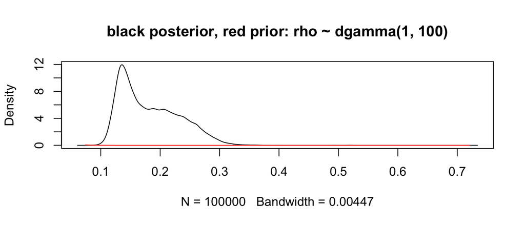

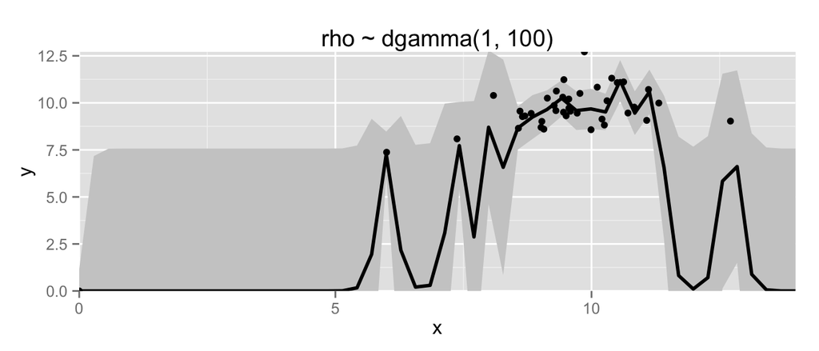

```r
plotPred(rhoPrior = quote(dgamma(1, 100)), ccap=10, crit=5, x0=6, niter=niter)
```

Although we can’t see it in the picture above, the prior for `rho` is decaying exponentially on the interval [.1, .4], which is causing the posterior to drop off over that region and beyond. Hence, we allow no substantial interations between points more than a fraction of a unit apart. In the prediction plot immediately above, predictions are dominated by the 0-mean everywhere not close to an input point. This obviously isn’t what we’re looking for.

Let’s let the data speak for itself, and see what the shape of the posterior distribution (for `rho`) actually looks like. We’ll do that by using a wide uniform prior for `rho` on the region [0, 200].

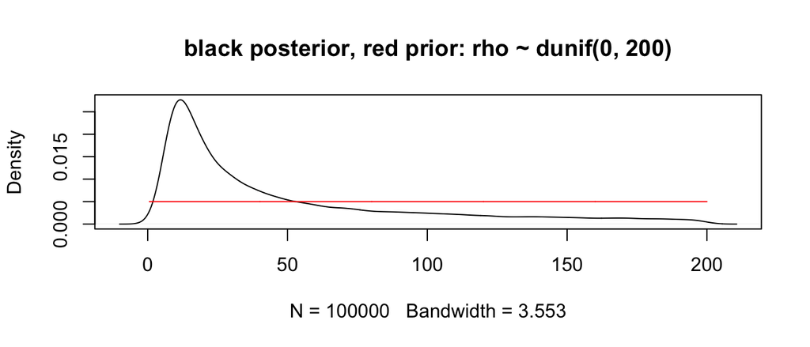

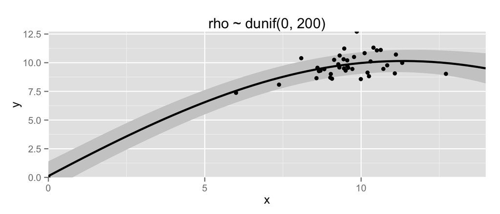

```r
plotPred(rhoPrior = quote(dunif(0, 200)), ccap=10, crit=5, x0=6, niter=niter)
```

It’s also worth looking at the effect of the “long length-scale” prior `rho ~ dgamma(100, 1)`, applied to long-scale dataset (scaled up by a factor of 10). This example is taken directly from non-dimensionalization.Rmd

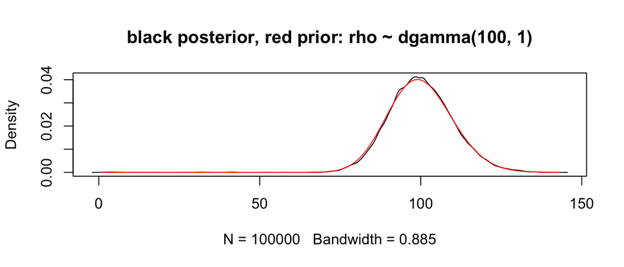

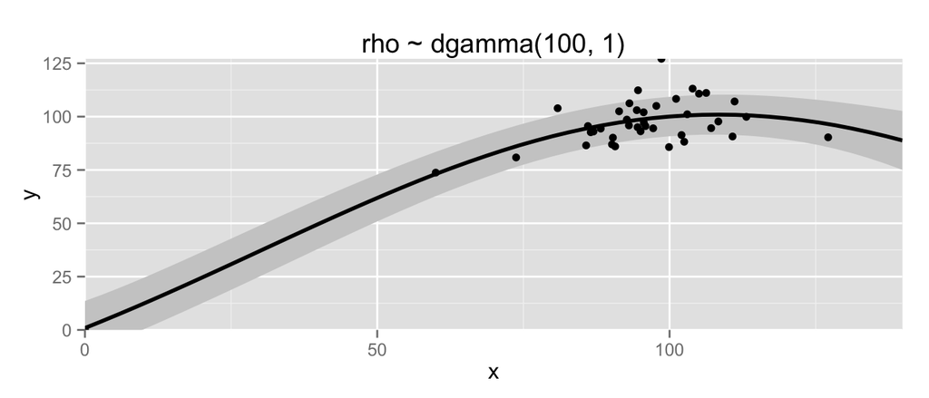

```r
plotPred(rhoPrior = quote(dgamma(100, 1)), ccap=100, crit=50, x0=60, niter=niter)
```

Here you see what I mentioned in my inital comment from [PR #5](https://github.com/cboettig/gpmanagement/pull/5): that for this prior, the posterior literally matches the prior exactly. Also, since the prior (and hence posterior) is only really non-zero around `rho = 100`, we again have prediction intervals the never widen. Still not what we want.

At least we’ve learned a lot about what’s going on, and various properties of that which we *don’t* desire!

## Dynamic Priors

Here, I followed [Munch, 2005](http://www.nrcresearchpress.com/doi/abs/10.1139/f05-073#.VeSxcbxViko), as you suggested. Not specifically his inverse-gamma priors, but the motivation behind choosing the parameters of the prior. Briefly:

The “range of dependence” is the distance $|x_i-x_j|$ between two predictors $x_i$ and $x_j$, such that the pairwise covariance of the associated observations $C_{i,j} \approx 0.05$. For notatational convenience, let’s denote the “range of dependence” as $ROD$.

$exp(-\tfrac{1}{2} ROD^2 / \rho^2) = 0.05$ $-\tfrac{1}{2} ROD^2 / \rho^2 \approx -3$ $ROD \approx \sqrt{6}\rho$

Munch used (somewhat arbitrarily) one-half of the range of the observed *x*’s as an estimate for $ROD$. Let’s denote the range of the observed *x*-values as $r_x$. This value for the $ROD$ determines a particular value of $\rho$, which I denote here as $\rho_{\text{mean}}$:

$ROD \approx \sqrt{6}\rho_{\text{mean}} = \tfrac{1}{2} r_x$ $\rho_{\text{mean}} = \tfrac{1}{2\sqrt{6}} r_x$

Finally, Munch selected the prior on his analagous parameter ($\phi$ in that paper) to have infinfinite variance, and mean $\rho_{\text{mean}}$.

Rather than using inverse-gamma priors with infinite variance, which seems opaque to me, I tried a uniform prior. The lower bound can safely be 0, since as we’ve seen the posterior distribution itself is naturally averse to values near to 0. For the upper bound, I (also somewhat arbitrarily) decided to use $\rho_{\text{mean}}$. Rational being (1) we don’t want points more than half the range of observed $x$’s apart to have a hugely significant interaction, and (2) the results come out very nicely.

To recap, we’ll try using the prior for `rho` as $\text{dunif}(0, \tfrac{1}{2\sqrt{6}} r_x)$, where $r_x$ is the range of the observed $x$-values.

Let’s see how this looks. First, for the short-scale data. We’ll also plot the priors and posteriors for `sigmaGP` and `sigmaOE`, to see how those look.

You can see what the `rho` prior distribution resolves to, i.e. what the upper-bound evaluates to in the context of the observed data, in the titles of the plots.

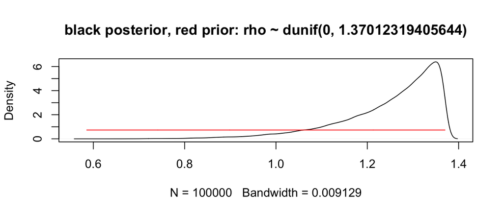

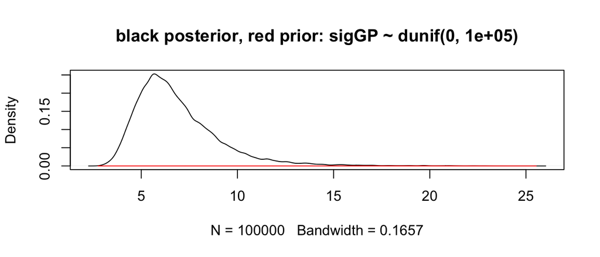

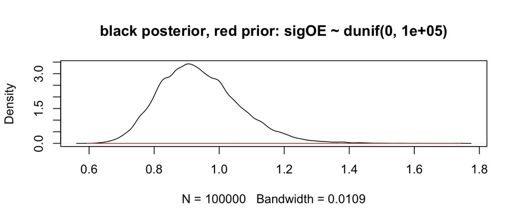

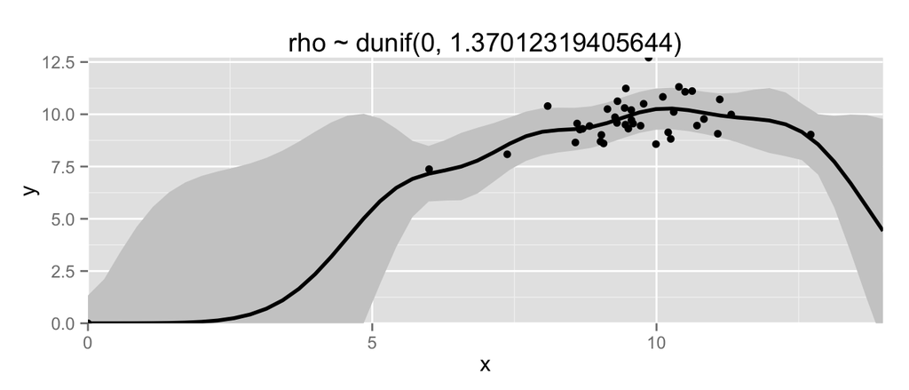

```r
plotPred(rhoPrior = quote(dunif(0, diff(range(xObs))/(2*sqrt(6)))),
         ccap=10, crit=5, x0=6, niter=niter,
         plotRhoDensity = TRUE, plotSigGPDensity = TRUE, plotSigOEDensity = TRUE)
```

Finally, let’s check that this prior has the intended scale-independent consequences. We’ll try using the same prior (which will resolve different numerically in this context), this time for the long-scale dataset.

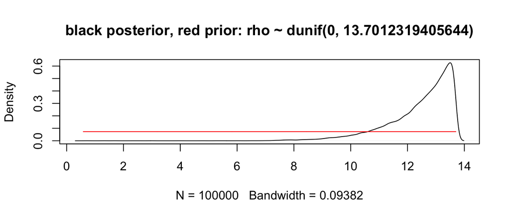

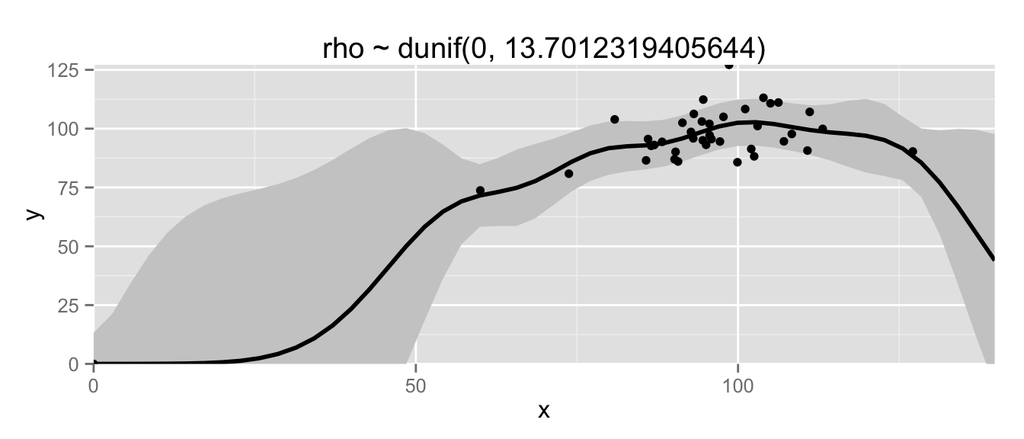

```r
plotPred(rhoPrior = quote(dunif(0, diff(range(xObs))/(2*sqrt(6)))),
         ccap=100, crit=50, x0=60, niter=niter)
```

Looks pretty reasonable, and has the intended consequences.

This begs the question, how do we feel about these “data-dependent” priors?